# Task 3 - Santa Barbara Urchins (Gracer)

Allison Gracer

10/25/2021

## Overview

**Data Citation:** Reed, D. 2020. SBC LTER: Reef: Long-term experiment: Kelp removal: Urchin size frequency distribution ver 20. Environmental Data Initiative. https://doi.org/10.6073/pasta/5a1e9ef03aa47bd2225c0bb98a02a63b.

## Setup

```r
# Attach packages
library(tidyverse)
library(here)
library(janitor)
library(kableExtra)
```

## Read in the data

```r
urchins <- read_csv(here("data", "urchins.csv")) %>% # read in data using here()
  clean_names() # convert all column headers to lower snake case
```

## Data visualization

#### Size comparison of purple and red urchins (includes data from all sites and for both treatments)

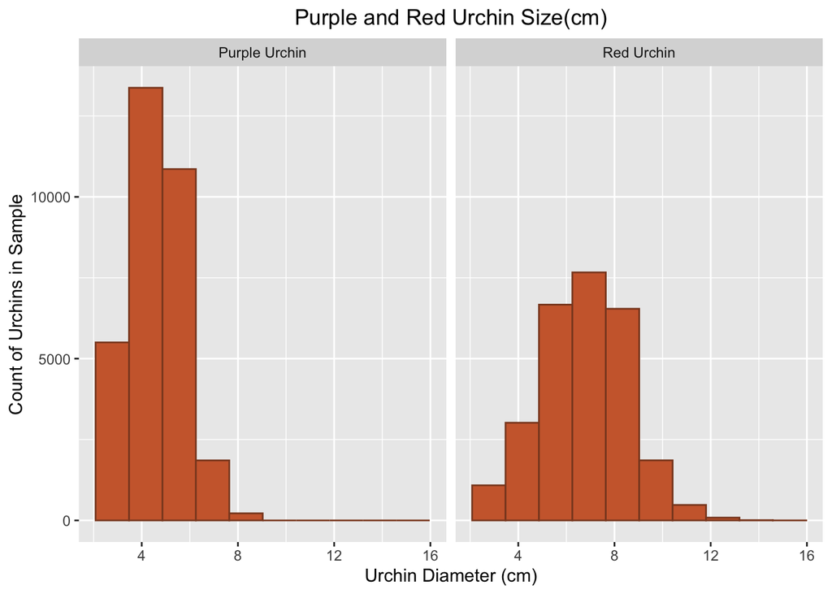

Figure 1. Comparing size of Purple and Red Urchins based on measurements of urchin diameter (cm), measured to the nearest 0.5 cm.

```r
ggplot(data = urchins, aes(x = size)) + # create a ggplot using urchins data, with size on x axis
  geom_histogram(fill = "sienna3", # specify plot type as histogram, and change graph colors and bin size
                 color = "sienna4",
                 bins = 10) +
  facet_wrap(~ common_name) + # facet data based on common_name
  labs(x = "Urchin Diameter (cm)", # label x axis
       y = "Count of Urchins in Sample", # label y axis
       title = "Purple and Red Urchin Size(cm)") + # create a plot title
  theme(plot.title = element_text(hjust = 0.5)) # center plot title
```

## Descriptive statistics table

#### Calculate mean, median, standard deviation, and sample size of urchin size (cm)

```r
urchins_stats <- urchins %>% # create a new data set called urchins_stats
  group_by(common_name) %>% # grouped by species (common_name)
  summarize(
    mean = round(mean(size),2), # calculate mean, and round to 2 decimal places
    median = median(size), # calculate median
    sd = round(sd(size),2), # calculate standard deviation, and round to 2 decimal places
    sample_size = n()) # calculate sample size
```

#### Finalized summary table of urchin size statistics

```r
kable(urchins_stats, # create simple table for rmarkdown with function kable()
      col.names = c("Common Name", "Mean(cm)", "Median(cm)", "Standard Deviation (cm)", "Sample Size"), # specify column names
      align = "c", # center column alignment
      caption = "Table 1: Purple and red urchin statistics for population samples collected along the Santa Barbara coast") %>%
  kable_paper() # changed table style
```

Table 1: Purple and red urchin statistics for population samples collected along the Santa Barbara coast

| Common Name | Mean(cm) | Median(cm) | Standard Deviation (cm) | Sample Size |
| --- | --- | --- | --- | --- |
| Purple Urchin | 4.47 | 4.5 | 1.18 | 31805 |
| Red Urchin | 6.78 | 7.0 | 1.89 | 27408 |

## Overall takeaways from the statystical analysis

When comparing the two species, the data shows that overall Red Urchins are larger, with a mean size of 6.78 (cm) and median size of 7.0 (cm). The Purple Urchins are smaller with a mean size of 4.47(cm) and a median size of 4.5(cm). Additionally, it is important to note that the Red Urchins have a larger standard deviation 1.89 (cm) compared to the Purple Urchins 1.18 (cm). The standard deviation values allow us to conclude that the Purple Urchins have a higher central tendency (smaller SD value), meaning the sample has less variation from the mean size. In non-stats jargon, we see less variation in size in the Purple Urchin population sample than we see in the Red Urchin population sample.